# Lesson 4

### Scatterplots and Perceived Audience Size

Notes:

- Scatterplots can visualize relationship between two continuous variables
- Perfect accuracy (diagonal line)

### Scatterplots

Notes:

- qplot with two continuous variables (x/y) creates scatterplot

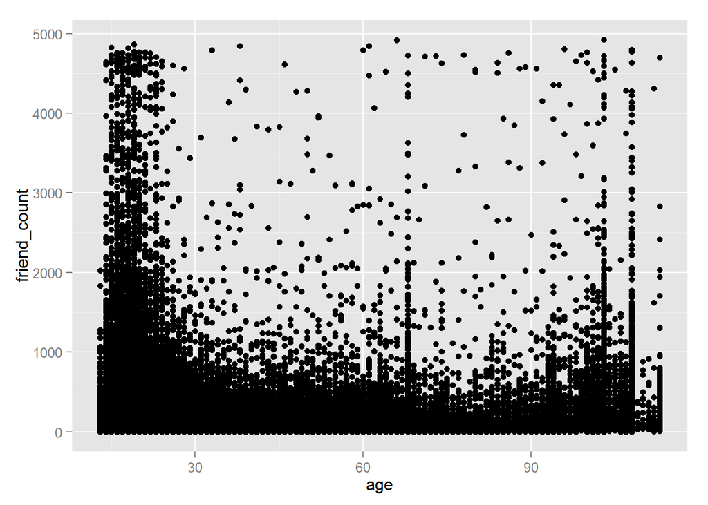

```r
library(ggplot2)
setwd('h:/Dokumente/GitHub/2015_Data_Analyst_Project_4/lesson4/')
pf <- read.csv('pseudo_facebook.tsv', sep='\t')
qplot(x=age, y=friend_count, data = pf)
```

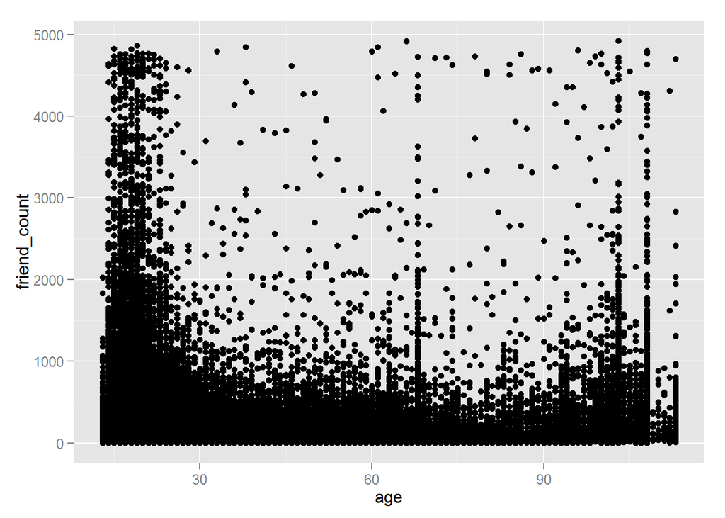

```r
qplot(age, friend_count, data=pf)
```

#### What are some things that you notice right away?

Response:

- older people seem to have less friends (or their friend_count is in the lower numbers)
- younger people (teenagers) seem to have the most users with many friends and a wide range of friends
- vertical bars (where users might have lied about their ages / fake accounts?)

### ggplot Syntax

Notes:

- needs `geom_...()` function
- x/y wrapped in `aes(...)` wrapper

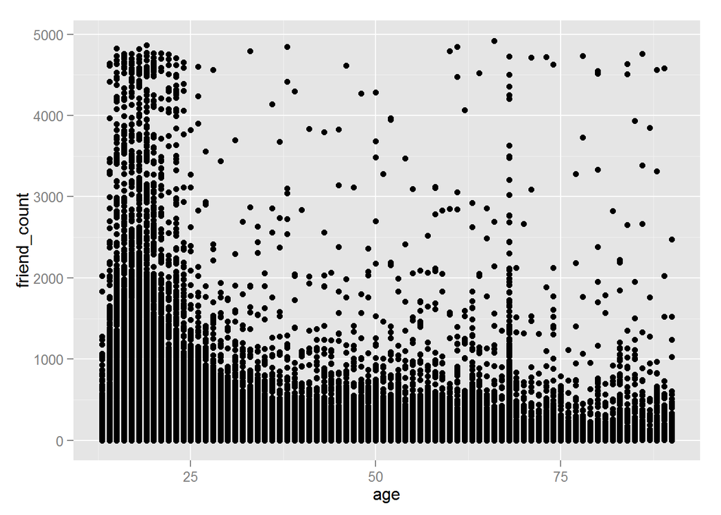

```r
ggplot(aes(x=age, y=friend_count), data=pf) + geom_point() +
  xlim(13,90)
```

```r
summary(pf$age)
```

```
##    Min. 1st Qu.  Median    Mean 3rd Qu.    Max.
##   13.00   20.00   28.00   37.28   50.00  113.00
```

### Overplotting

Notes:

- too man plot points on the same continuous values
- use `geom_jitter(...)` to add noise and `alpha=...` to overlay points over each other

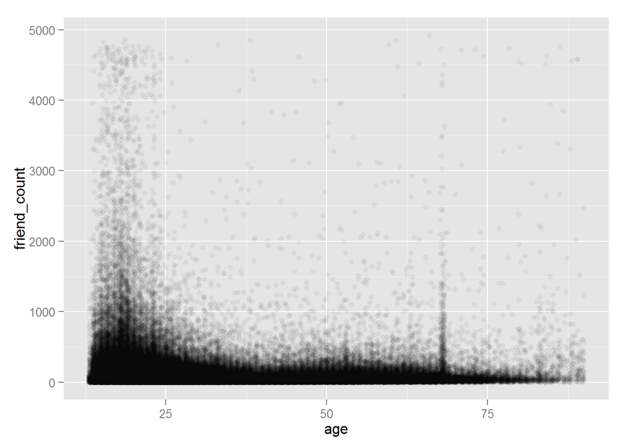

```r
ggplot(aes(x=age, y=friend_count), data=pf) + geom_jitter(alpha=1/20) +
  xlim(13,90)
```

#### What do you notice in the plot?

Response:

- still clearly visible “bins” for age ranges
- now much more clearly visible: distribution of friend_counts in each age range

### Coord_trans()

Look up the documentation for `coord_trans()` and add a layer to the plot that transforms friend_count using the square root function. Create your plot!

Notes:

- use `coord_trans(x=..., y=...)` to transform scales, e.g. by `log10` or `sqrt`
- be careful with jittering transformed coordinate systems (noise can move data into negative numbers, leads to imaginary results)
- to specify that just x needs to be jittered, supply `position = position_jitter(h = 0)`

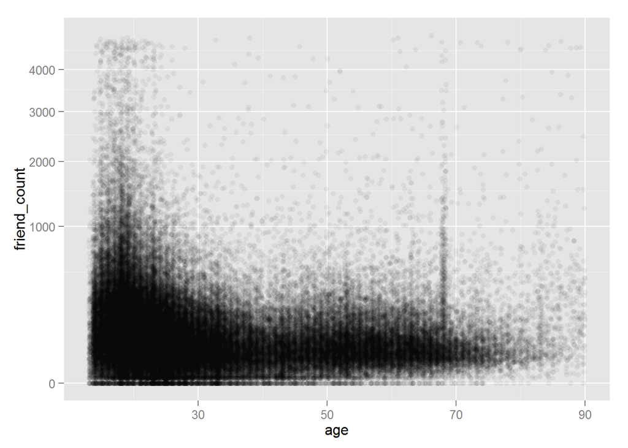

```r
ggplot(aes(x=age, y=friend_count), data=pf) +
  geom_point(alpha=1/20, position = position_jitter(h = 0)) +
  xlim(13,90) +
  coord_trans(y="sqrt")
```

### Alpha and Jitter

Notes: - Explore relationship between friends initiated vs. age - Similar distribution than friend count but more homogenous distributions in lower ages

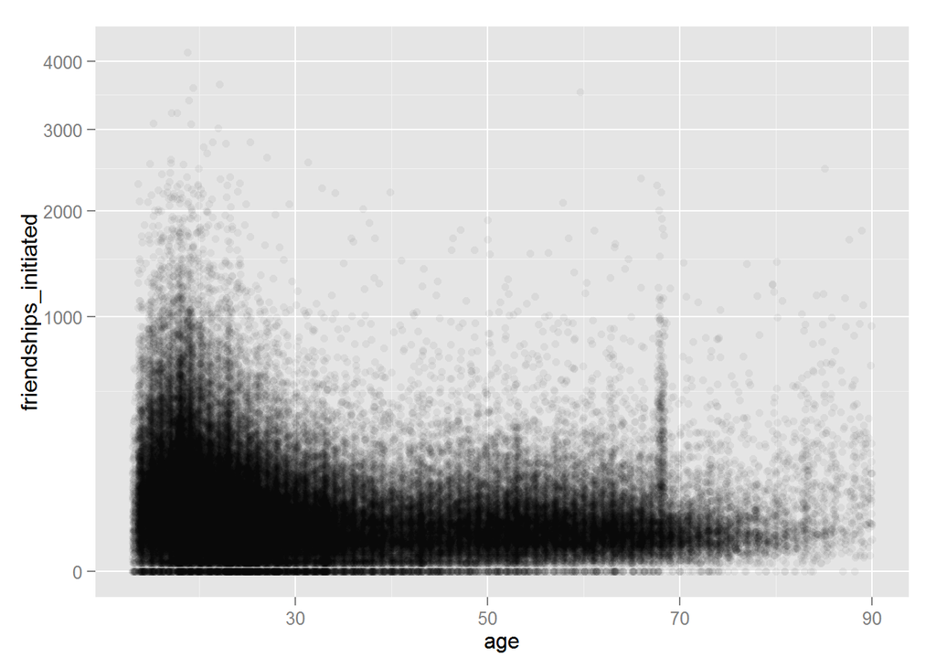

```r
ggplot(aes(x=age, y=friendships_initiated),  data=pf) +
  geom_point(alpha=1/20, position = position_jitter(h = 0)) +
  xlim(13,90) +
  coord_trans(y="sqrt")
```

### Overplotting and Domain Knowledge

Notes:

- It might make sense to see the x/y variable in terms of percentiles of another variable…

### Conditional Means

Notes:

- use `dplyr::filter(...)`, `dplyr::arrange(...)`, `dplyr::group_by(...)`, `dplyr::mutate(...)`, `dplyr::summarize(...)` for data munging

```r
library(dplyr)
age.groups <- group_by(pf, age)
pf.fc_by_age <- summarise(age.groups,
          friend_count_mean = mean(friend_count),
          friend_count_median = median(friend_count),
          n = n())
pf.fc_by_age <- arrange(pf.fc_by_age, age)
head(pf.fc_by_age)
```

```
## Source: local data frame [6 x 4]
##
##     age friend_count_mean friend_count_median     n
##   (int)             (dbl)               (dbl) (int)
## 1    13          164.7500                74.0   484
## 2    14          251.3901               132.0  1925
## 3    15          347.6921               161.0  2618
## 4    16          351.9371               171.5  3086
## 5    17          350.3006               156.0  3283
## 6    18          331.1663               162.0  5196
```

```r
# also works:

pf.fc_by_age <- pf %>%
  group_by(age) %>%
  summarise(friend_count_mean = mean(friend_count),
          friend_count_median = median(friend_count),
          n = n()) %>%
  arrange(age)
```

Create your plot!

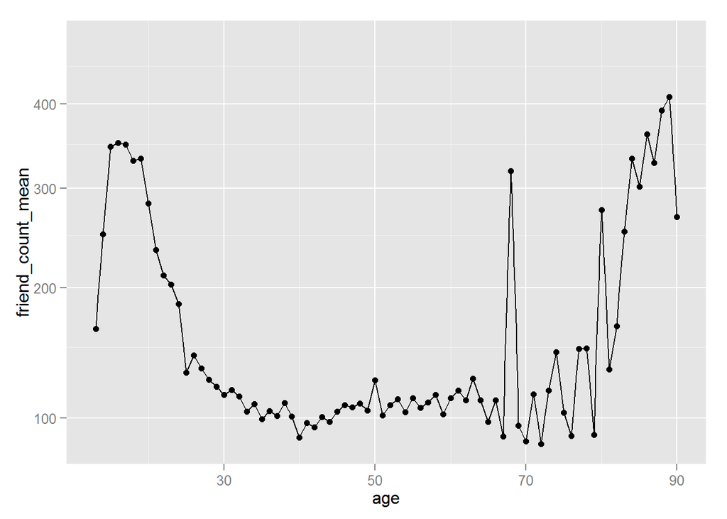

```r
ggplot(aes(x=age, y=friend_count_mean), data=pf.fc_by_age) +
  geom_line() +
  geom_point() +
  xlim(13,90) +
  coord_trans(y="sqrt")
```

### Overlaying Summaries with Raw Data

Notes:

- `geom_line(stat='summary', fun.y=f)` layer adds a line with any function `f` applied to the y variables (e.g., `mean`)

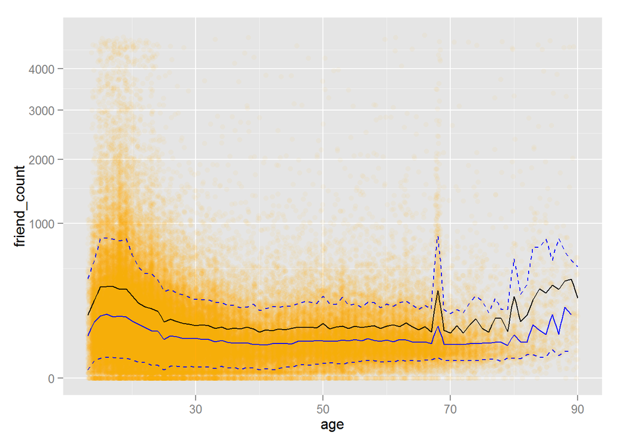

```r
ggplot(aes(x=age, y=friend_count),  data=pf) +
  geom_point(alpha=1/20, position = position_jitter(h = 0), color='orange') +
  geom_line(stat='summary', fun.y=mean) +
  geom_line(stat='summary', fun.y=quantile, probs = .1, linetype=2, color='blue') +
  geom_line(stat='summary', fun.y=quantile, probs = .9, linetype=2, color='blue') +
  geom_line(stat='summary', fun.y=quantile, probs = .5, color='blue') +
  coord_cartesian() +
  xlim(13,90) +
  coord_trans(y="sqrt")
```

#### What are some of your observations of the plot?

Response:

### Moira: Histogram Summary and Scatterplot

See the Instructor Notes of this video to download Moira’s paper on perceived audience size and to see the final plot.

Notes:

- [Bernstein, M. S., Bakshy, E., Burke, M., & Karrer, B. (2013). Quantifying the invisible audience in social networks. In Proceedings of the SIGCHI Conference on Human Factors in Computing Systems (CHI 2013), pp. 21-30.](http://hci.stanford.edu/publications/2013/invisibleaudience/invisibleaudience.pdf)
- Histograms can be used to pair raw data to summary data
- Show: How much people over-/underestimate by a certain percentage range (= histogram bin)

### Correlation

Notes:

- Summarizes a strength of a relation between two variables
- Pearson Product Moment Correlation

```r
cor.test(pf$age, pf$friend_count, method='pearson')
```

```
##
##  Pearson's product-moment correlation
##
## data:  pf$age and pf$friend_count
## t = -8.6268, df = 99001, p-value < 2.2e-16
## alternative hypothesis: true correlation is not equal to 0
## 95 percent confidence interval:
##  -0.03363072 -0.02118189
## sample estimates:
##         cor
## -0.02740737
```

```r
with(pf, cor.test(age, friend_count, method='pearson'))
```

```
##
##  Pearson's product-moment correlation
##
## data:  age and friend_count
## t = -8.6268, df = 99001, p-value < 2.2e-16
## alternative hypothesis: true correlation is not equal to 0
## 95 percent confidence interval:
##  -0.03363072 -0.02118189
## sample estimates:
##         cor
## -0.02740737
```

Look up the documentation for the cor.test function.

What’s the correlation between age and friend count? Round to three decimal places. Response: -0.02740737

### Correlation on Subsets

Notes:

```r
with(subset(pf, age<=70), cor.test(age, friend_count))
```

```
##
##  Pearson's product-moment correlation
##
## data:  age and friend_count
## t = -52.592, df = 91029, p-value < 2.2e-16
## alternative hypothesis: true correlation is not equal to 0
## 95 percent confidence interval:
##  -0.1780220 -0.1654129
## sample estimates:
##        cor
## -0.1717245
```

### Correlation Methods

Notes:

- [Correlation Methods: Pearson’s r, Spearman’s rho, and Kendall’s tau](http://www.statisticssolutions.com/correlation-pearson-kendall-spearman/)
- Can be used in `method` parameter of `cor.test(...)`

## Create Scatterplots

Notes:

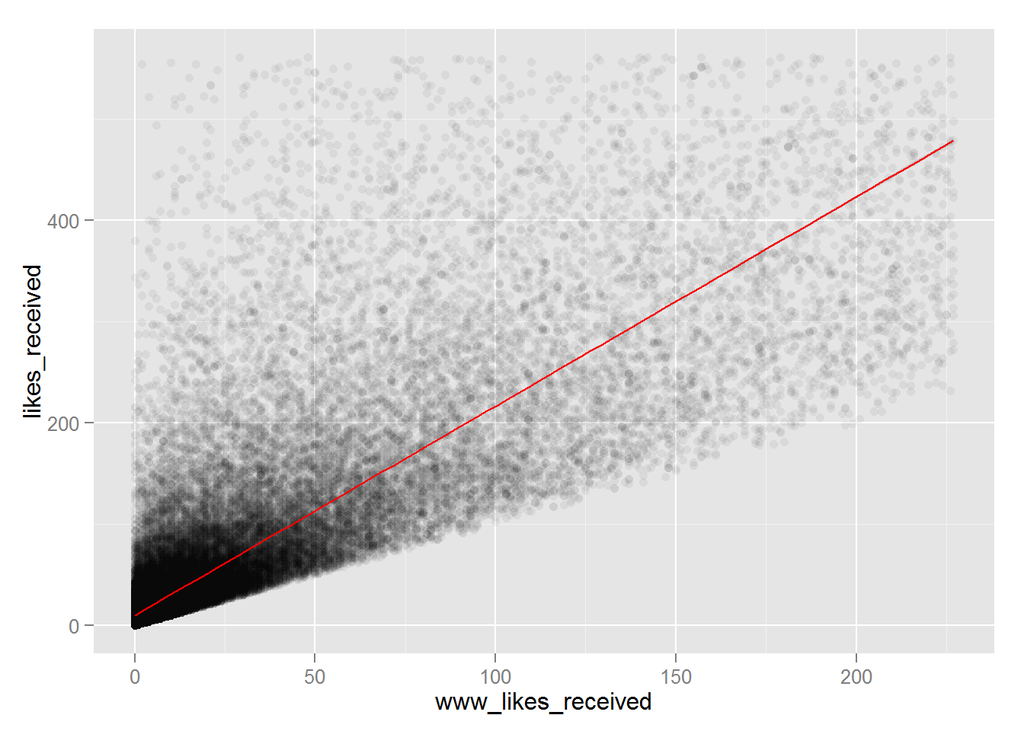

```r
ggplot(aes(x=www_likes_received, y=likes_received),  data=pf) +
  geom_point(alpha=1/20) +
  coord_cartesian() +
  xlim(0,quantile(pf$www_likes_received, 0.95)) +
  ylim(0,quantile(pf$likes_received, 0.95)) +
  geom_smooth(method="lm", color="red")
```

### Strong Correlations

Notes:

- In case `likes_received` vs. `www_likes_received` variables are closely related because one is the subset of the other

```r
cor.test(pf$www_likes_received, pf$likes_received)
```

```
##
##  Pearson's product-moment correlation
##
## data:  pf$www_likes_received and pf$likes_received
## t = 937.1, df = 99001, p-value < 2.2e-16
## alternative hypothesis: true correlation is not equal to 0
## 95 percent confidence interval:
##  0.9473553 0.9486176
## sample estimates:
##       cor
## 0.9479902
```

What’s the correlation betwen the two variables? Include the top 5% of values for the variable in the calculation and round to 3 decimal places.

Response: 0.9479902

### Moira on Correlation

Notes:

- Measuring correlation is important because sometimes regression models assume that variables are independent from each other
- In case of highly correlated (dependent) variables it will be difficult to tell, which variable causes a certain outcome

### More Caution with Correlation

Notes:

- Corellation helps us determine which variables are related / dependent on each other
- But careful: Corellation coefficients can be decepted

```r
# install.packages('alr3')
library(alr3)
data(Mitchell)
```

Create your plot!

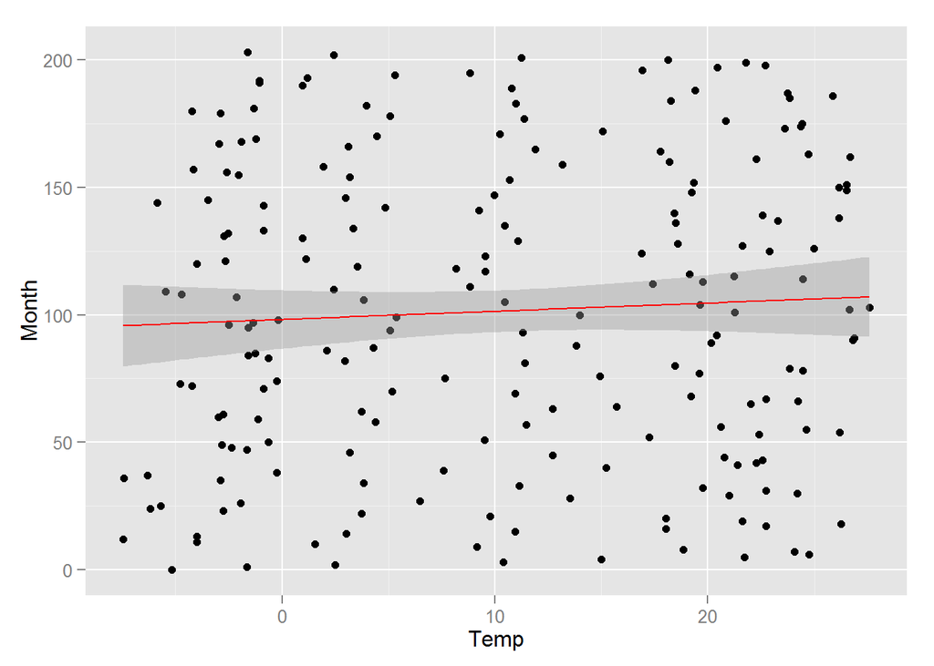

```r
ggplot(aes(x=Temp, y=Month), data=Mitchell) +
  geom_point() +
  coord_cartesian() +
  geom_smooth(method="lm", color="red")
```

### Noisy Scatterplots

1. Take a guess for the correlation coefficient for the scatterplot.

Answer: around 0?

2. What is the actual correlation of the two variables? (Round to the thousandths place)

Answer: 0.05747063

```r
cor.test(Mitchell$Month, Mitchell$Temp)
```

```
##
##  Pearson's product-moment correlation
##
## data:  Mitchell$Month and Mitchell$Temp
## t = 0.81816, df = 202, p-value = 0.4142
## alternative hypothesis: true correlation is not equal to 0
## 95 percent confidence interval:
##  -0.08053637  0.19331562
## sample estimates:
##        cor
## 0.05747063
```

### Making Sense of Data

Notes:

- The months keep repeating over and over
- Looking at the data on a year-by-year base with `scale_x_discrete`

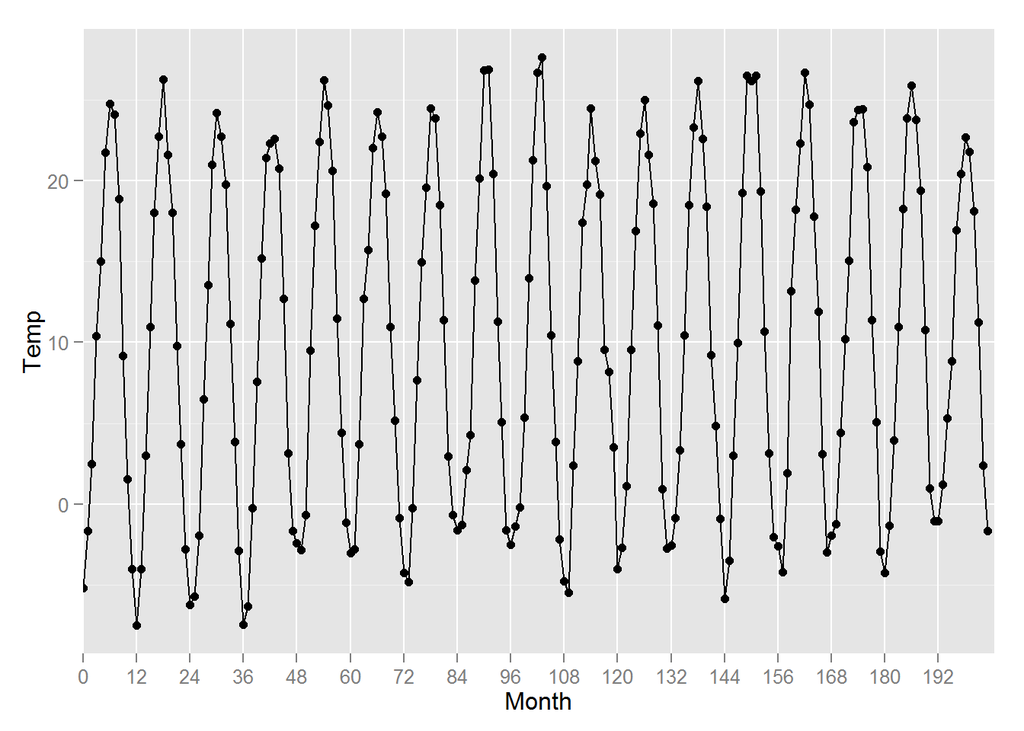

```r
ggplot(aes(y=Temp, x=Month), data=Mitchell) +
  geom_point() +
  geom_line() +
  coord_cartesian() +
  scale_x_discrete(breaks = seq(0,203,12))
```

### A New Perspective

What do you notice?

Response: Peaks in every summer!

Watch the solution video and check out the Instructor Notes!

Notes:

- The cor and cor.test functions determine the strength of a linear relationship, but they may miss other relationships in the data

### Understanding Noise: Age to Age Months

Notes:

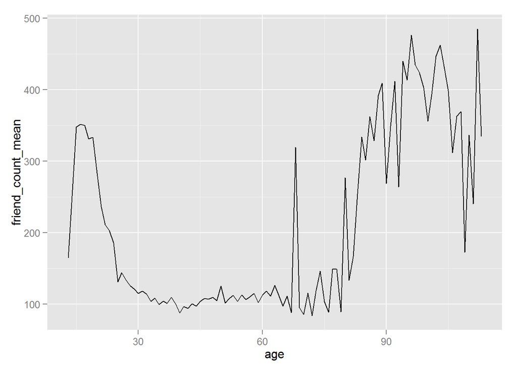

```r
library(ggplot2)
ggplot(aes(x=age, y=friend_count_mean), data=pf.fc_by_age) +
    geom_line()
```

```r
pf$age_with_months <- pf$age + (12-pf$dob_month)/12
```

### Age with Months Means

Notes:

- Now we group by age with month and calculate the aggregate mean

```r
library(dplyr)
pf.fc_by_age_months <- pf %>%
  dplyr::group_by(age_with_months) %>%
  dplyr::summarise(friend_count_mean=mean(friend_count),
                 friend_count_median=median(friend_count),
                 n=n()) %>%
  dplyr::arrange(age_with_months)

head(pf.fc_by_age_months)
```

```
## Source: local data frame [6 x 4]
##
##   age_with_months friend_count_mean friend_count_median     n
##             (dbl)             (dbl)               (dbl) (int)
## 1        13.16667          46.33333                30.5     6
## 2        13.25000         115.07143                23.5    14
## 3        13.33333         136.20000                44.0    25
## 4        13.41667         164.24242                72.0    33
## 5        13.50000         131.17778                66.0    45
## 6        13.58333         156.81481                64.0    54
```

### Noise in Conditional Means

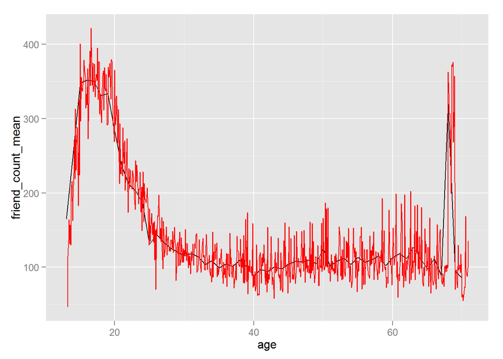

```r
library(ggplot2)
ggplot(aes(x=age, y=friend_count_mean), data=subset(pf.fc_by_age, age<71)) +
  geom_line() +
  geom_line(aes(x=age_with_months, y=friend_count_mean), data=subset(pf.fc_by_age_months, age_with_months<71), color='red')
```

### Smoothing Conditional Means

Notes:

- using “age with month” effectively decreased the bin size for each sample - therefore the noise increases - **Bias/Variance Tradeoff**

```
## geom_smooth: method="auto" and size of largest group is <1000, so using loess. Use 'method = x' to change the smoothing method.
## geom_smooth: method="auto" and size of largest group is <1000, so using loess. Use 'method = x' to change the smoothing method.
## geom_smooth: method="auto" and size of largest group is <1000, so using loess. Use 'method = x' to change the smoothing method.
```

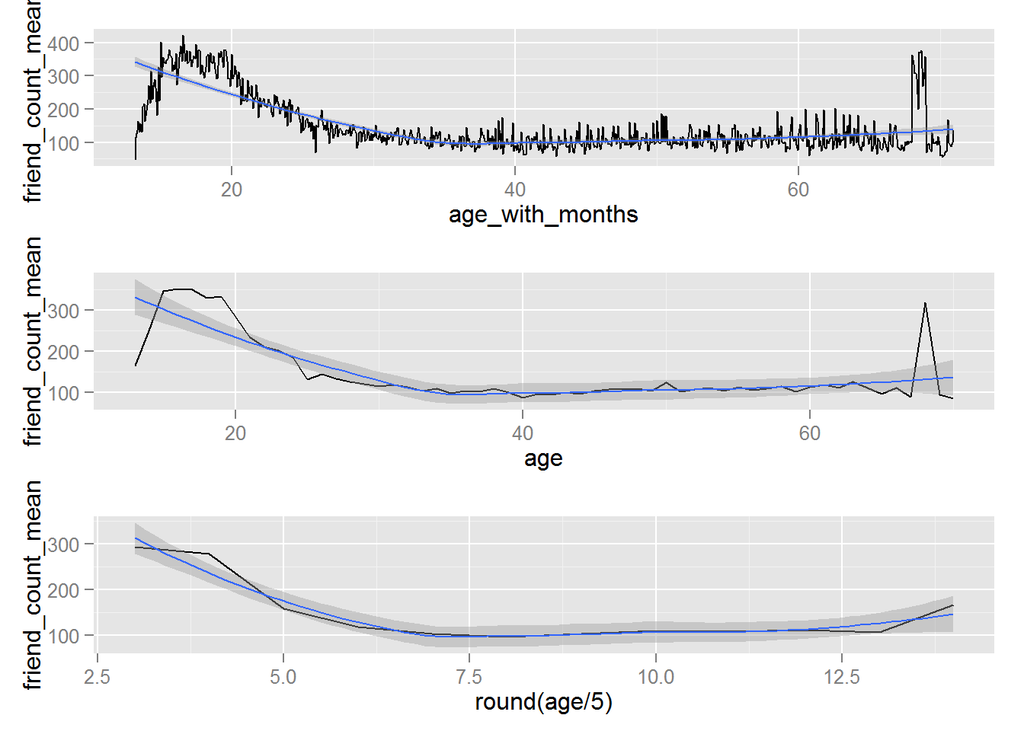

```r
p1 <- ggplot(aes(x=age, y=friend_count_mean), data=subset(pf.fc_by_age, age<71)) +
  geom_line() + geom_smooth()
p2 <- ggplot(aes(x=age_with_months, y=friend_count_mean), data=subset(pf.fc_by_age_months, age_with_months<71)) +
  geom_line() + geom_smooth()
p3 <- ggplot(aes(x=round(age/5), y=friend_count_mean), data=subset(pf.fc_by_age, age<71)) +
  geom_line(stat='summary', fun.y=mean) + geom_smooth()
library(gridExtra)
grid.arrange(p2, p1, p3, ncol=1)
```

### Which Plot to Choose?

Notes:

- In exploratory data analysis you do not often have to choose
- You can create different plots. :)
- Later versions of plots are not always better than earlier ones, just show different insights

### Analyzing Two Variables

Reflection:

- how to fine-tune bin sizes in R
- review on how to use dplyr
- review on corellation and how to use it in R
- review on regression and how to use it in R
- with(…) function which resolved for me, why in R we sometimes write df$var and sometimes just var
- really understanding the %>% operator
- review on how to plot two variables against each other (already played around with that during the Gapminder data in problem set 3)

Reflection from Instructors:

- scatter plots and conditional summaries in them
- using jitter and transparancy
- get some insights when to really trust our data (and when rather not to)

Click **KnitHTML** to see all of your hard work and to have an html page of this lesson, your answers, and your notes!